# R Notebook

# Multiple Regression Homework

## MVP

### 1.

Load the housing_prices.csv data set and undertake an initial exploration of the data.

```r
library(tidyverse)
library(janitor)
library(GGally)
library(ggfortify)
```

```r
house_prices <- read_csv("data/housing_prices.csv")
```

```r
glimpse(house_prices)
```

```
Rows: 19,675
Columns: 10
$ longitude          <dbl> -122.23, -122.22, -122.24, -122.25, -122.25, -122.25, -122.25, -122.25, -122.26…
$ latitude           <dbl> 37.88, 37.86, 37.85, 37.85, 37.85, 37.85, 37.84, 37.84, 37.84, 37.84, 37.85, 37…
$ housing_median_age <dbl> 41, 21, 52, 52, 52, 52, 52, 52, 42, 52, 52, 52, 52, 52, 52, 50, 52, 52, 50, 52,…
$ total_rooms        <dbl> 880, 7099, 1467, 1274, 1627, 919, 2535, 3104, 2555, 3549, 2202, 3503, 2491, 696…
$ total_bedrooms     <dbl> 129, 1106, 190, 235, 280, 213, 489, 687, 665, 707, 434, 752, 474, 191, 626, 283…
$ population         <dbl> 322, 2401, 496, 558, 565, 413, 1094, 1157, 1206, 1551, 910, 1504, 1098, 345, 12…
$ households         <dbl> 126, 1138, 177, 219, 259, 193, 514, 647, 595, 714, 402, 734, 468, 174, 620, 264…
$ median_income      <dbl> 8.3252, 8.3014, 7.2574, 5.6431, 3.8462, 4.0368, 3.6591, 3.1200, 2.0804, 3.6912,…
$ median_house_value <dbl> 452600, 358500, 352100, 341300, 342200, 269700, 299200, 241400, 226700, 261100,…
$ ocean_proximity    <chr> "NEAR BAY", "NEAR BAY", "NEAR BAY", "NEAR BAY", "NEAR BAY", "NEAR BAY", "NEAR B…
```

```r
summary(house_prices)
```

```
   longitude         latitude     housing_median_age  total_rooms    total_bedrooms     population
 Min.   :-124.3   Min.   :32.54   Min.   : 1.00      Min.   :    2   Min.   :   2.0   Min.   :    3
 1st Qu.:-121.8   1st Qu.:33.93   1st Qu.:18.00      1st Qu.: 1438   1st Qu.: 297.0   1st Qu.:  796
 Median :-118.5   Median :34.27   Median :28.00      Median : 2111   Median : 436.0   Median : 1179
 Mean   :-119.6   Mean   :35.65   Mean   :28.39      Mean   : 2620   Mean   : 539.6   Mean   : 1441
 3rd Qu.:-118.0   3rd Qu.:37.73   3rd Qu.:37.00      3rd Qu.: 3120   3rd Qu.: 648.0   3rd Qu.: 1746
 Max.   :-114.3   Max.   :41.95   Max.   :52.00      Max.   :39320   Max.   :6445.0   Max.   :35682
                                                                     NA's   :200
   households     median_income     median_house_value ocean_proximity
 Min.   :   2.0   Min.   : 0.4999   Min.   : 14999     Length:19675
 1st Qu.: 282.0   1st Qu.: 2.5268   1st Qu.:116600     Class :character
 Median : 411.0   Median : 3.4500   Median :173800     Mode  :character
 Mean   : 501.2   Mean   : 3.6767   Mean   :192478
 3rd Qu.: 606.0   3rd Qu.: 4.5826   3rd Qu.:248200
 Max.   :6082.0   Max.   :15.0001   Max.   :500000
```

Impute NAs

```r
house_prices <- house_prices %>%
  mutate(total_bedrooms = coalesce(total_bedrooms, median(total_bedrooms, na.rm = TRUE)))
```

### 2.

We expect the total_rooms of houses to be strongly correlated with total_bedrooms. Use ggpairs() to investigate correlations between these two variables.

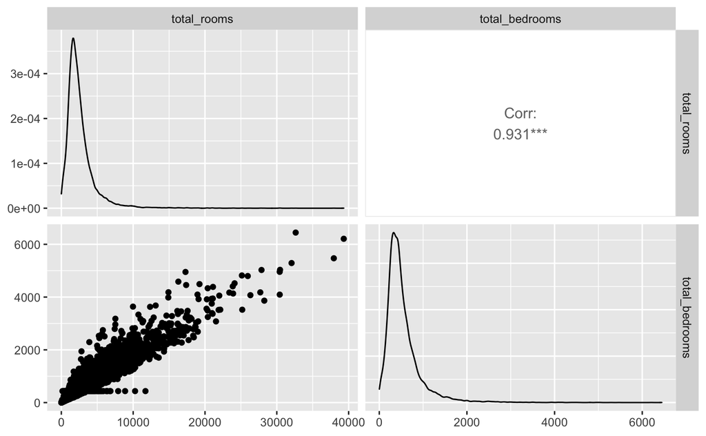

### 3.

So, we do find significant correlations. Let’s drop total_bedrooms from the dataset, and use only total_rooms going forward

```r
house_prices <- house_prices %>%
  select(-total_bedrooms)
```

### 4.

We are interested in developing a regression model for the median_house_value of a house in terms of the possible predictor variables in the dataset.

Use ggpairs() to investigate correlations between median_house_value and the predictors (this may take a while to run, don’t worry, make coffee or something).

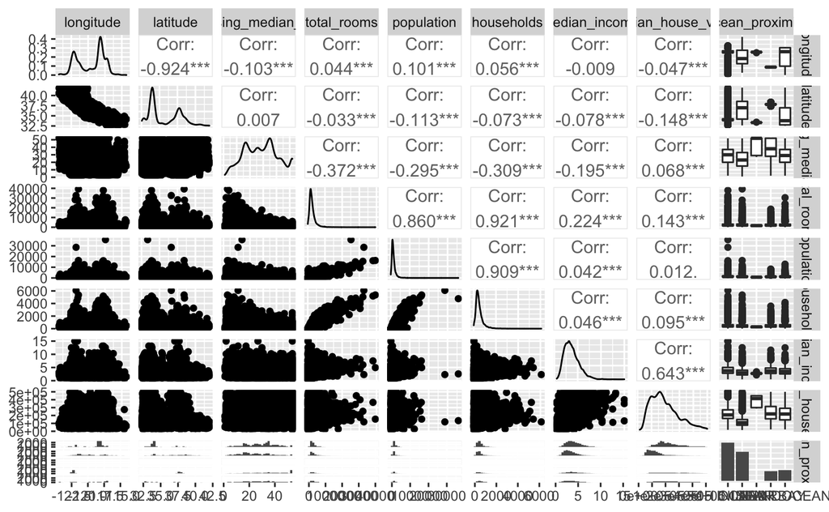

Perform further ggplot visualisations of any significant correlations you find.

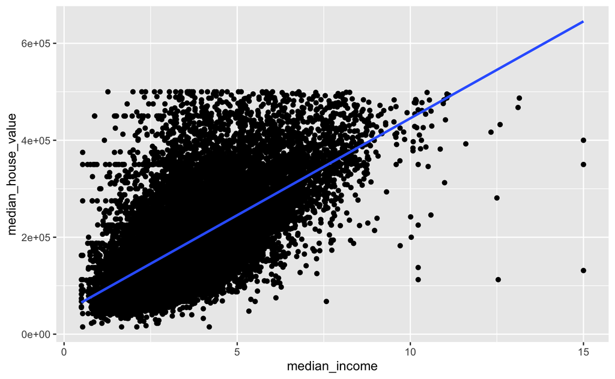

```r
house_prices %>%
  ggplot(aes(x = median_income, y = median_house_value)) +
  geom_point() +
  geom_smooth(method = "lm", se = FALSE)
```

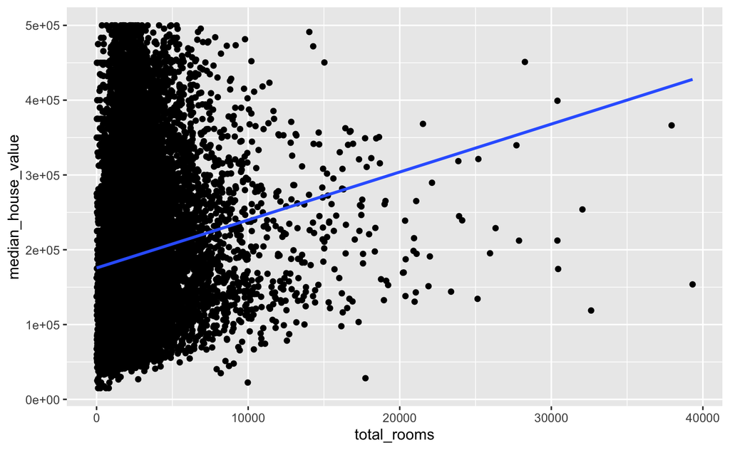

```r
house_prices %>%
  ggplot(aes(x = total_rooms, y = median_house_value)) +
  geom_point() +
  geom_smooth(method = "lm", se = FALSE)
```

### 5.

Shortly we may try a regression model to fit the categorical predictor ocean_proximity. Investigate the level of ocean_proximity predictors. How many dummy variables do you expect to get from it?

| ocean_proximity |
| --- |
| NEAR BAY |
| <1H OCEAN |
| INLAND |
| NEAR OCEAN |
| ISLAND |

> Expect to get 4 dummy variables, one less than the number of distinct values.

### 6.

Start with simple linear regression. Regress median_house_value on median_income and check the regression diagnostics.

```r
summary(lm_1)
```

```
Call:
lm(formula = median_house_value ~ median_income, data = house_prices)

Residuals:
    Min      1Q  Median      3Q     Max
-513966  -51564  -13979   36549  403935

Coefficients:
              Estimate Std. Error t value Pr(>|t|)
(Intercept)    45457.0     1359.0   33.45   <2e-16 ***
median_income  39987.0      339.9  117.64   <2e-16 ***
---
Signif. codes:  0 ‘***’ 0.001 ‘**’ 0.01 ‘*’ 0.05 ‘.’ 0.1 ‘ ’ 1

Residual standard error: 74870 on 19673 degrees of freedom
Multiple R-squared:  0.4129,    Adjusted R-squared:  0.4129
F-statistic: 1.384e+04 on 1 and 19673 DF,  p-value: < 2.2e-16
```

### 7.

Add another predictor of your choice. Check your assumptions, diagnostics, and interpret the model.

```r
summary(lm_2)
```

```
Call:
lm(formula = median_house_value ~ median_income + households,
    data = house_prices)

Residuals:
    Min      1Q  Median      3Q     Max
-503916  -51272  -13518   35541  408958

Coefficients:
               Estimate Std. Error t value Pr(>|t|)
(Intercept)   37786.407   1497.173   25.24   <2e-16 ***
median_income 39799.451    339.047  117.39   <2e-16 ***
households       16.681      1.389   12.01   <2e-16 ***
---
Signif. codes:  0 ‘***’ 0.001 ‘**’ 0.01 ‘*’ 0.05 ‘.’ 0.1 ‘ ’ 1

Residual standard error: 74600 on 19672 degrees of freedom
Multiple R-squared:  0.4172,    Adjusted R-squared:  0.4172
F-statistic:  7042 on 2 and 19672 DF,  p-value: < 2.2e-16
```

(rough interpretation, I’m not good with numbers) > a 1 unit (I’m not sure what the unit is here, $10000) increase in an area’s median income results in a $40,000 increase in the median house value, with all other predictors being held constant. > an additional household results in a $16 increase in an area’s median house value, if all other predictors are held constant.  
> 41% of the variation of the median house value can be explained by the median income and number of households